# A Guide to Data Analysis using R

by [Myo Minn Oo](https://myominnoo.github.io/) - last updated on 05 September 2020

### 0.0.1 Model Diagnostics

So far, we have learned how to run linear regression in R, with some methods of checking the data. Unless we verify that our data meet the assumptions under linear regression, the results may be misleading. In this section, we will explore how we can use R to check whether our data satisfy the assumptions. This section was based on UCLA’s `STATA` tutorial series.[^1]

We will focus on the following assumptions.

```
- Linearity
      The relationships between the predictors and the outcome variable should be linear.
- Normality
      The errors should be normally distributed – technically normality is necessary only for hypothesis tests to be valid, estimation of the coefficients only requires that the errors be identically and independently distributed
- Homogeneity of variance (homoscedasticity)
      The error variance should be constant
- Independence
      The errors associated with one observation are not correlated with the errors of any other observation.
```

In this section, we use an example dataset called `crime`. This dataset is from Statistical Methods for Social Sciences, Third Edition by Alan Agresti, and Barbara Finlay (Prentice Hall, 1997). Detail can be read here.[^2]

Variables

1. sid - id
2. state - state name
3. crime - violent crimes per 100,000 people
4. murder - murders per 1,000,000
5. pctmetro - the percentage of the population living in metropolitan areas
6. pctwhite - the percentage of the white population
7. pcths - the percentage of the population with high school education and above
8. poverty - the percentage of the population living under the poverty line
9. single - the percentage of the population that are single parents

We want to predict `crime` based on `pctmetro`, `poverty`, and `single`. That is to say, we want to build a linear regression model between the response variable `crime` and the independent variables `pctmetro`, `poverty`, and `single`.

First, let’s import this dataset into R.

```r
## Import crime dataset
crime <- haven::read_dta("https://stats.idre.ucla.edu/stat/stata/webbooks/reg/crime.dta")

## Check the dataset
codebook(crime)
```

```
#> ________________________________________________________________
#>
#> Codebook: 'crime'
#> ________________________________________________________________
#>
#>  No Variable |              Label      Type Obs_Num <NA> <NA>(%)
#>  -- -------- + ------------------ --------- ------- ---- -------
#>   1      sid |               <NA>   numeric      51    0       0
#>   2    state |               <NA> character      51    0       0
#>   3    crime | violent crime rate   numeric      51    0       0
#>   4   murder |        murder rate   numeric      51    0       0
#>   5 pctmetro |   pct metropolitan   numeric      51    0       0
#>   6 pctwhite |          pct white   numeric      51    0       0
#>   7    pcths |   pct hs graduates   numeric      51    0       0
#>   8  poverty |        pct poverty   numeric      51    0       0
#>   9   single |  pct single parent   numeric      51    0       0
#>  -- -------- + ------------------ --------- ------- ---- -------
#> ________________________________________________________________
#> (Dataset Label: crime data from agresti & finlay - 1997)
```

#### 0.0.1.1 Influential data

Often you deal with a dataset where a single observation can make a huge difference in the regression output if it is substantially different from all other observations. In this case, you need to investigate this further. There are three ways that observations can be unusually different.

1. Outliers

They are **large residuals** in linear regression. An outlier often represents data entry error.

2. Leverage points

An extreme value in a predictor variable is called high leverage point.

3. Influential points

If removing such extreme values or high leverage points substantially changes the coefficient estimates, such values are called influential points.

Let’s create a scatter plot matrix on variables, `crime`, `pctmetro`, `poverty`, and `single`.

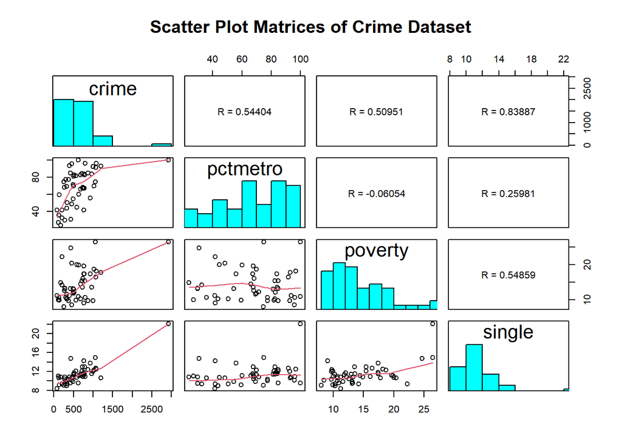

```r
## Scatter plot matrices
crime %>%
  select(crime, pctmetro, poverty, single) %>%
  scatterPlotMatrix(main = "Scatter Plot Matrices of Crime Dataset")
```

We see a data point that is far away from the rest of the data in every plot. Let’s make individual plots so that we can get a better view. We also add labels to these data points so that we know which state these data points come from.

**Scatter plots with data labels**

Below we use `text` function from base R to add labels to the data points. Check the help page by running `?text`.

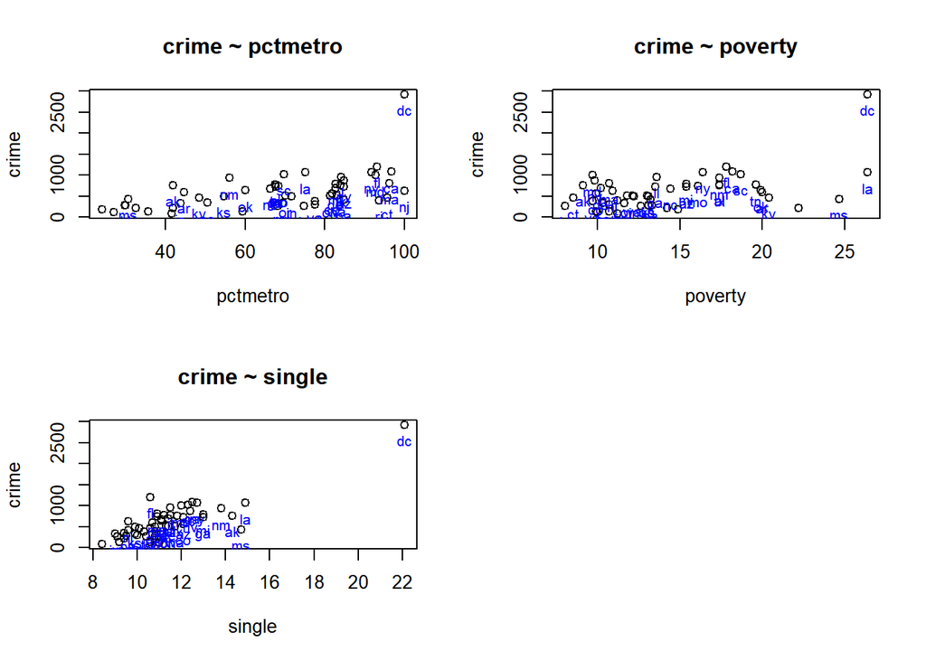

```r
## Set graphs parameter
par(mfrow = c(2, 2))

## Plot crime and pctmetro
plot(crime ~ pctmetro, data = crime, main = "crime ~ pctmetro")
crime %$% text(crime ~ pctmetro, labels = state,
               cex = 0.8, pos = 1, col = "blue")

## Plot crime and poverty
plot(crime ~ poverty, data = crime, main = "crime ~ poverty")
crime %$% text(crime ~ poverty, labels = state,
               cex = 0.8, pos = 1, col = "blue")

## Plot crime and single
plot(crime ~ single, data = crime, main = "crime ~ single")
crime %$% text(crime ~ single, labels = state,
               cex = 0.8, pos = 1, col = "blue")

## Reset graphs parameter
par(mfrow = c(1, 1))
```

We see the data point that is far away from the rest of the data comes from `DC` state. Since it stands out, we can say this is an outlier and leverage point. We keep this in mind while we continue fitting the linear model.

**Fitting a linear model**

Let’s fit the model and run `regress`.

```r
## Fit the model
fit <- lm(crime ~ pctmetro + poverty + single, data = crime)

## Generate regression output
## Set decimal point to 2 to make the output fit the page width
reg <- regress(fit, rnd = 2)
```

```
#> _________________________________________________________________________
#>
#>                 Linear Regression Output
#> _________________________________________________________________________
#>
#>          Stats |    Value             Source |    DF         SS        MS
#>  ------------- + --------         ---------- + ----- ---------- ---------
#>  Number of Obs |       51              Model |     3  8170480.2 2723493.4
#>       F(3, 47) |    82.16           Residual |    47  1557994.5   33148.8
#>       Prob > F |     0.00         ---------- + ----- ---------- ---------
#>      R-Squared |     0.84              Total |    50  9728474.7  194569.5
#>  Adj R-Squared |     0.83
#>            AIC |   681.41                              Root MSE    182.07
#>  ------------- + -------- ------- ------------ ----- ---------- ---------
#>          crime |    Coef. Std.Err            t P>|t| [95% Conf. Interval]
#>  ------------- + -------- ------- ------------ ----- ---------- ---------
#>       pctmetro |     7.83    1.25         6.24  0.00       5.37     10.29
#>        poverty |    17.68    6.94         2.55  0.01       4.08     31.28
#>         single |   132.41   15.50         8.54  0.00     102.02    162.79
#>    (Intercept) | -1666.44  147.85       -11.27  0.00   -1956.23  -1376.65
#>  ------------- + -------- ------- ------------ ----- ---------- ---------
#> _________________________________________________________________________
#> (Fit: lm(formula = crime ~ pctmetro + poverty + single, data = crime))
#> (pctmetro: pct metropolitan)
#> (poverty: pct poverty)
#> (single: pct single parent)
#> (crime: violent crime rate)
```

Next, we are going to generate studentized residuals, leverage values, and Cook’s distance values from the model to identify the potentially unusual or influential points.

Below we use `predict` function to generate the data with these statistics, and store the result to `rstd`.

```r
## Generate diagnostic statistics
rstd <- predict(reg)

## Check the dataset
codebook(rstd)
```

```
#> _____________________________________________________________________
#>
#> Codebook: 'rstd'
#> _____________________________________________________________________
#>
#>  No  Variable |                  Label      Type Obs_Num <NA> <NA>(%)
#>  -- --------- + ---------------------- --------- ------- ---- -------
#>   1     crime |                   <NA>   numeric      51    0       0
#>   2  pctmetro |                   <NA>   numeric      51    0       0
#>   3   poverty |                   <NA>   numeric      51    0       0
#>   4    single |                   <NA>   numeric      51    0       0
#>   5       sid |                   <NA>   numeric      51    0       0
#>   6     state |                   <NA> character      51    0       0
#>   7    murder |                   <NA>   numeric      51    0       0
#>   8  pctwhite |                   <NA>   numeric      51    0       0
#>   9     pcths |                   <NA>   numeric      51    0       0
#>  10    fitted |          Fitted values   numeric      51    0       0
#>  11     resid |              Residuals   numeric      51    0       0
#>  12 std.resid |  Studentized Residuals   numeric      51    0       0
#>  13       hat | Leverage or hat values   numeric      51    0       0
#>  14     sigma |              hat sigma   numeric      51    0       0
#>  15    cooksd |        Cook's Distance   numeric      51    0       0
#>  -- --------- + ---------------------- --------- ------- ---- -------
#> _____________________________________________________________________
```

The studentized residuals are stored under the variable, `std.resid`, leverage under `hat` and Cook’s distance under `cooksd`.

**Boxplots for residuals**

Let’s check the studentized residuals with `boxplot`.

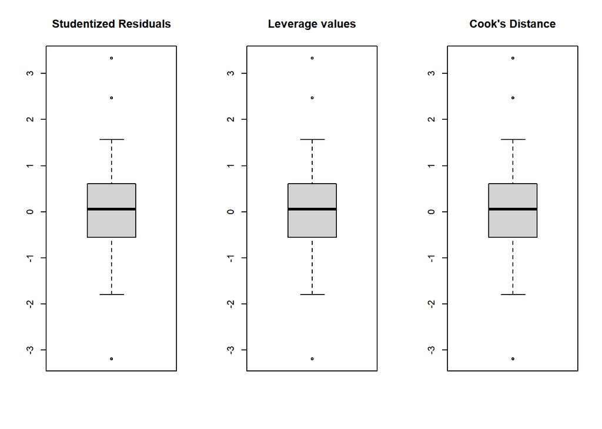

```r
## Set graphs parameter
par(mfrow = c(1, 3))

## Boxplot
rstd %$% boxplot(std.resid, main = "Studentized Residuals")
rstd %$% boxplot(std.resid, main = "Leverage values")
rstd %$% boxplot(std.resid, main = "Cook's Distance")
```

```r
## Set graphs parameter
par(mfrow = c(1, 1))
```

**Studentized Residuals**

We want to see which state has studentized residuals over +2 or under -2. We do this by listing a few lines from the top and the bottom. We use `head` and `tail` functions from base R to get top and bottom rows.

```r
## Check top rows
rstd %>%
  arrange(std.resid) %>%
  select(sid, state, std.resid) %>%
  head
```

```
#>   sid state std.resid
#> 1  25    ms -3.193796
#> 2  18    la -1.793716
#> 3  39    ri -1.653521
#> 4  47    wa -1.294313
#> 5  35    oh -1.144457
#> 6  48    wi -1.126045
```

```r
## Check bottom rows
rstd %>%
  arrange(std.resid) %>%
  select(sid, state, std.resid) %>%
  tail
```

```
#>    sid state std.resid
#> 46  16    ks  1.074898
#> 47  14    il  1.147723
#> 48  13    id  1.284314
#> 49  12    ia  1.564434
#> 50   9    fl  2.470016
#> 51  51    dc  3.327972
```

We should pay attention to studentized residuals that exceed +2 or -2, and get even more concerned about residuals that exceed +2.5 or -2.5 and even yet more concerned about residuals that exceed +3 or -3. These results show that DC and MS are the most worrisome observations followed by FL.

Below we use `abs` function to get absolute values of studentized residuals that are greater than 2.

```r
rstd %>%
  filter(abs(std.resid) > 2) %>%
  select(sid, state, std.resid, crime, pctmetro, poverty, single)
```

```
#>   sid state std.resid crime pctmetro poverty single
#> 1   9    fl  2.470016  1206     93.0    17.8   10.6
#> 2  51    dc  3.327972  2922    100.0    26.4   22.1
#> 3  25    ms -3.193796   434     30.7    24.7   14.7
```

We see the data for the three potential outliers we identified, namely Florida, Mississippi, and Washington D.C. Looking carefully at these three observations, we couldn’t find any data entry error, though we may want to do another regression analysis with the extreme point such as DC deleted.

**Leverage value**

Below we also list 6 largest values of leverage or hat values along with variables in the regression model.

```r
## List 6 largest leverage values
rstd %>%
  arrange(hat) %>%
  select(sid, state, hat, crime, pctmetro, poverty, single) %>%
  tail
```

```
#>    sid state       hat crime pctmetro poverty single
#> 46  46    vt 0.1362576   114     27.0    10.0   11.0
#> 47  18    la 0.1652769  1062     75.0    26.4   14.9
#> 48  49    wv 0.1802005   208     41.8    22.2    9.4
#> 49  25    ms 0.1910120   434     30.7    24.7   14.7
#> 50   1    ak 0.2606759   761     41.8     9.1   14.3
#> 51  51    dc 0.5363830  2922    100.0    26.4   22.1
```

The state `DC` also has the largest leverage values.

As a rule of thumb, a data point with leverage value greater than `(2k + 2) / n` should be carefully checked, where k is the number of predictors and n is the number of observations. In our case, we got 3 predictors and 51 observations, hence `(2 * 3 + 2) / 51 =` 0.1568627.

```r
## List variables in the regression model if leverage > 0.156
rstd %>%
  filter(hat > 0.156) %>%
  arrange(hat) %>%
  select(sid, state, hat, crime, pctmetro, poverty, single)
```

```
#>   sid state       hat crime pctmetro poverty single
#> 1  18    la 0.1652769  1062     75.0    26.4   14.9
#> 2  49    wv 0.1802005   208     41.8    22.2    9.4
#> 3  25    ms 0.1910120   434     30.7    24.7   14.7
#> 4   1    ak 0.2606759   761     41.8     9.1   14.3
#> 5  51    dc 0.5363830  2922    100.0    26.4   22.1
```

Similar to the studentized residuals, `DC` has the largest leverage value.

We can also plot the leverage by the studentized residuals to look for observations that are high on both measures. The points we would examine are values in the upper right or lower right corners, which are outside the red dashed Cook’s distance line. These are points that would be influential in the model and removing them would likely noticeably alter the regression results. This is a quick way of checking potential influential observations and outliers at the same time. Both types of points are of great concern to us.

Below we create the graph by inputting `reg` into `plot` function.

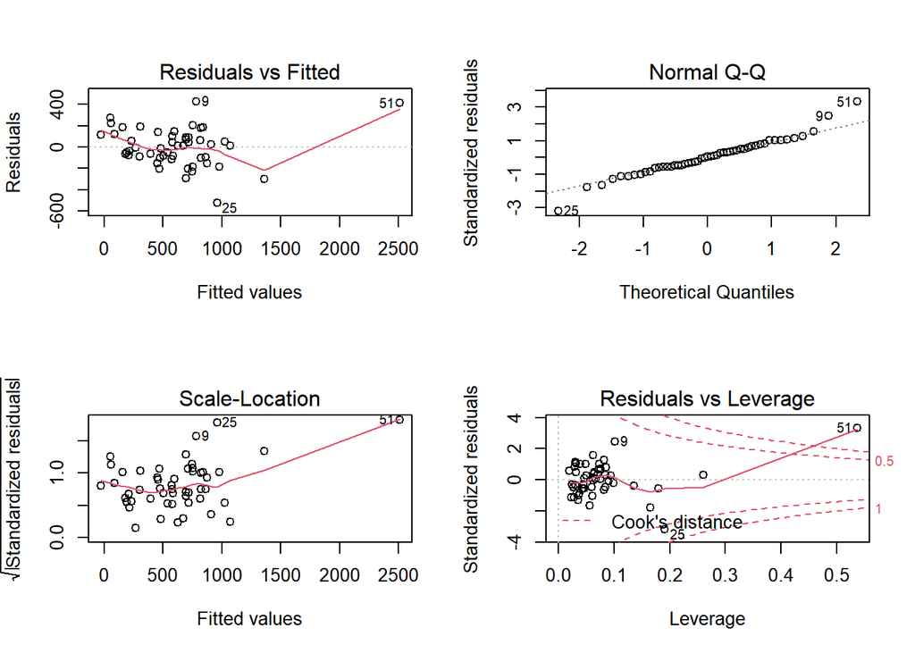

```r
## Leverage versus residuals plot
plot(reg)
```

We see two data points with row numbers 51 and 25 are outside the Cook’s distance which is indicated by two red dashed lines. They need to be checked carefully. As it turns out, row 51 and 25 corresponds to the state, `DC` and `MS`.

```r
## List variables if state == dc or ms: note R is case-sensitive
rstd %>%
  filter(state == "dc" | state == "ms") %>%
  select(sid, state, std.resid, hat, crime, pctmetro, poverty, single)
```

```
#>   sid state std.resid      hat crime pctmetro poverty single
#> 1  51    dc  3.327972 0.536383  2922    100.0    26.4   22.1
#> 2  25    ms -3.193796 0.191012   434     30.7    24.7   14.7
```

**Cook’s Distance**

Let’s move on to Cook’s distance, which combines information on the residual and leverage. The lowest possible value is zero, and the higher the Cook’Distance is, the more influential the point is. The conventional cut-off point is `4 / n`.

Below we list all observations with the Cook’s distance that is greater than `4 / 51`.

```r
## List all variables if Cook's D > 4 / 51
rstd %>%
  filter(cooksd > (4 / 51)) %>%
  select(sid, state, std.resid, cooksd, hat, crime, pctmetro, poverty, single)
```

```
#>   sid state std.resid    cooksd       hat crime pctmetro poverty single
#> 1  18    la -1.793716 0.1592638 0.1652769  1062     75.0    26.4   14.9
#> 2   9    fl  2.470016 0.1736290 0.1022025  1206     93.0    17.8   10.6
#> 3  51    dc  3.327972 3.2034289 0.5363830  2922    100.0    26.4   22.1
#> 4  25    ms -3.193796 0.6021060 0.1910120   434     30.7    24.7   14.7
```

The `DC`’s Cook’s Distance is by far the largest.

**avPlots**

Finally, we create added-variable plots to identify influential points. These are also called partial-regression plots since they help us to evaluate the residuals of a predictor variable while holding the other predictors constant.

Below we use `avPlots` from `car` package.

```r
## Install car pacakage if you don't have it.
install.packages("car")
```

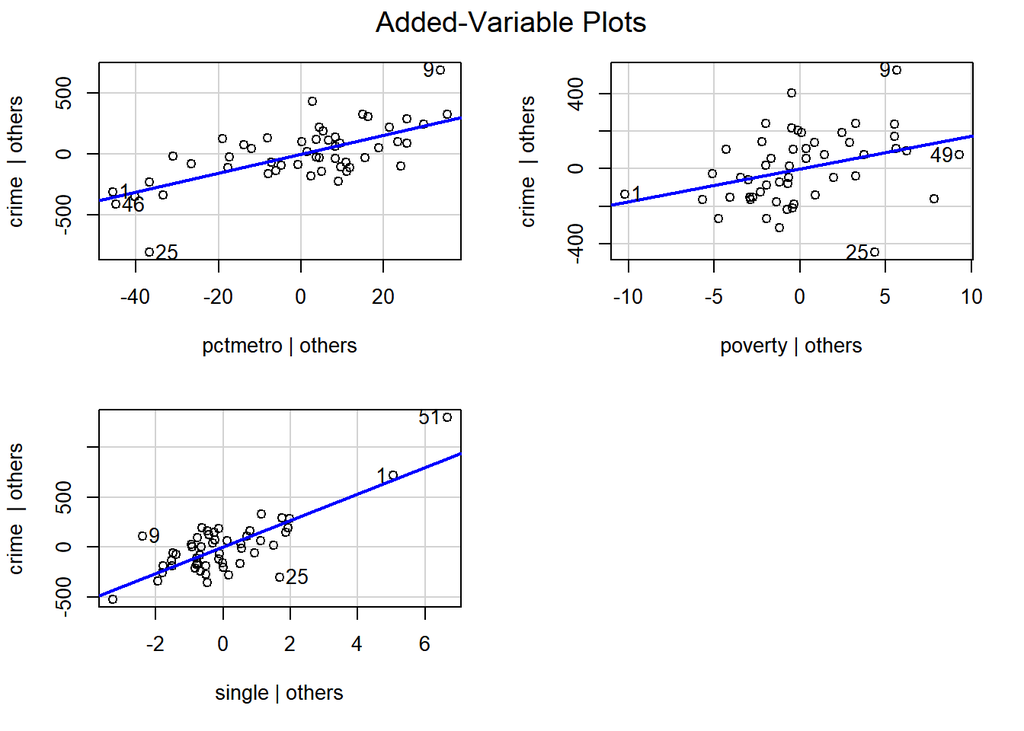

```r
## Create avPlots by inputting our model fit
car::avPlots(fit)
```

In the last `avplot` for single, the graph shows `crime` by `single` after both `crime` and `single` has been adjusted for all other predictors in the model. The line plotted has the same slope as the coefficient for `single`. This plot shows how the observation for `DC` influences the coefficient. You can see how the regression line is tugged upwards trying to fit through the extreme value of `DC` (51). `Alaska` (1) and `West Virginia` (the lowest data point) may also exert substantial leverage on the coefficient of `single`.

```
DC has appeared as an outlier as well as an influential point in every analysis. Since DC is not a state, we can use this to justify omitting it from the analysis saying that we wish to just analyze states.
```

Let’s run `regress` by removing the state `DC`.

```r
## Remove dc row
crime2 <- crime %>%
  filter(state != "dc")

## Fit linear model using dataset with dc row removed
fit <-  lm(crime ~ pctmetro + poverty + single, data = crime2)

## Regression report with 2 decimal points
regress(fit, rnd = 2)
```

```
#> _________________________________________________________________________
#>
#>                 Linear Regression Output
#> _________________________________________________________________________
#>
#>          Stats |    Value             Source |    DF         SS        MS
#>  ------------- + --------         ---------- + ----- ---------- ---------
#>  Number of Obs |       50              Model |     3  3098767.1 1032922.4
#>       F(3, 46) |    39.90           Residual |    46  1190858.1   25888.2
#>       Prob > F |     0.00         ---------- + ----- ---------- ---------
#>      R-Squared |     0.72              Total |    49  4289625.2   87543.4
#>  Adj R-Squared |     0.70
#>            AIC |   655.80                              Root MSE    160.90
#>  ------------- + -------- ------- ------------ ----- ---------- ---------
#>          crime |    Coef. Std.Err            t P>|t| [95% Conf. Interval]
#>  ------------- + -------- ------- ------------ ----- ---------- ---------
#>       pctmetro |     7.71    1.11         6.95  0.00       5.54      9.89
#>        poverty |    18.28    6.14         2.98  0.00       6.26     30.31
#>         single |    89.40   17.84         5.01  0.00      54.44    124.36
#>    (Intercept) | -1197.54  180.49        -6.64  0.00   -1551.29   -843.78
#>  ------------- + -------- ------- ------------ ----- ---------- ---------
#> _________________________________________________________________________
#> (Fit: lm(formula = crime ~ pctmetro + poverty + single, data = crime2))
#> (pctmetro: pct metropolitan)
#> (poverty: pct poverty)
#> (single: pct single parent)
#> (crime: violent crime rate)
```

#### 0.0.1.2 Normality

Normality of residuals is only required for the validity of hypothesis testing so that p-values for t-test and F-test will be valid. It is not required to get unbiased estimates of the regression coefficients.

```
OLS regression merely requires that the residuals (errors) be identically and independently distributed. Furthermore, there is no assumption or requirement that the predictor variables be normally distributed. If this were the case than we would not be able to use dummy coded variables in our models.
```

We use the `elemapi2` data we imported in previous section on Simple Linear Regression. Let’s fit a model for academic performance (`api00`) using three predictors: percentage of students receiving free meals (`meals`), percentage of English language learners (`ell`), and percentage of teachers with emergency credentials (`emer`).

```r
## Fit the model
fit <- lm(api00 ~ meals + ell + emer, data = elemapi2)

## Generate regression output
reg <- regress(fit)
```

```
#> ____________________________________________________________________________
#>
#>                 Linear Regression Output
#> ____________________________________________________________________________
#>
#>          Stats |     Value             Source |      DF         SS        MS
#>  ------------- + ---------         ---------- + ------- ---------- ---------
#>  Number of Obs |       400              Model |       3  6749782.7 2249927.6
#>      F(3, 396) |    673.00           Residual |     396  1323889.3    3343.2
#>       Prob > F |   0.00000         ---------- + ------- ---------- ---------
#>      R-Squared |   0.83602              Total |     399  8073672.0   20234.8
#>  Adj R-Squared |   0.83478
#>            AIC |   4387.00                                Root MSE     57.82
#>  ------------- + --------- ------- ------------ ------- ---------- ---------
#>          api00 |     Coef. Std.Err            t   P>|t| [95% Conf. Interval]
#>  ------------- + --------- ------- ------------ ------- ---------- ---------
#>          meals |  -3.15919 0.14974       -21.10 0.00000   -3.45267  -2.86570
#>            ell |  -0.90987 0.18464        -4.93 0.00000   -1.27178  -0.54797
#>           emer |  -1.57350 0.29311        -5.37 0.00000   -2.14800  -0.99900
#>    (Intercept) | 886.70326 6.25976       141.65 0.00000  874.43414 898.97239
#>  ------------- + --------- ------- ------------ ------- ---------- ---------
#> ____________________________________________________________________________
#> (Fit: lm(formula = api00 ~ meals + ell + emer, data = elemapi2))
#> (meals: pct free meals)
#> (ell: english language learners)
#> (emer: pct emer credential)
#> (api00: api 2000)
```

There are two ways to check the noramlity of residuals: Normal quantile plot and Shapiro-Wilk test of normality.

Below we create a normal quantile plot by inputting `reg` into `plot` function.

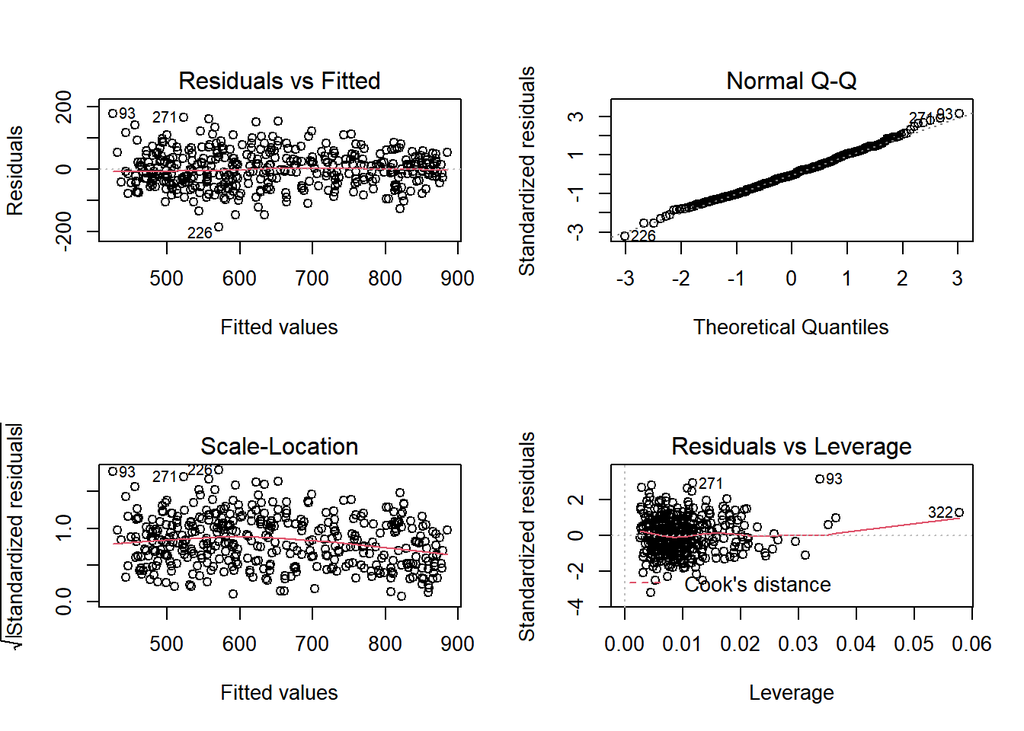

```r
## Plots for linear model diagnostics
plot(reg)
```

We have seen this plot matrix when we discussed MLR. The second plot is the normal quantile plot. If the data points should fall nicely along the dashed line, we say the residuals are normally distributed.

Next we run numerical test on residual data by `summ` funtion. We generate residuals data by inputting `reg` into `predict` function. The residuals are stored in the variable `resid`.

```r
## Generate residuals
rstd <- predict(reg)

## summary statistic on `resid` variable
summ(rstd, resid)
```

```
#> ___________________________________________________________________________
#>
#> Summary
#> ___________________________________________________________________________
#>
#>  Variables | Obs. NA. Mean Std.Dev Median    Q1   Q3    Min   Max Normality
#>  --------- + ---- --- ---- ------- ------ ----- ---- ------ ----- ---------
#>      resid |  400   0 -0.0    57.6   -3.7 -40.0 36.4 -185.5 178.5     0.510
#>  --------- + ---- --- ---- ------- ------ ----- ---- ------ ----- ---------
#> ___________________________________________________________________________
#> (resid: Residuals)
```

Look the p-value under the column `Normality`. Since p-value is very large (0.51), we conclude that the residual is normally distributed. This is consistent with that from the normal quantile plot described above.

#### 0.0.1.3 Homoscedasticity

One of the main assumptions of the linear regression is homoscedasticity of residuals. It means that the variances of residuals are constant across the data points. If the residuals are plotted against fitted values, they should not show any pattern. A commonly used graphical method is to plot the residual versus fitted values (or predicted values).

We have already seen this plot in the plot matrix above. It is the first plot.

Below we create this plot from the raw data of `predict` function.

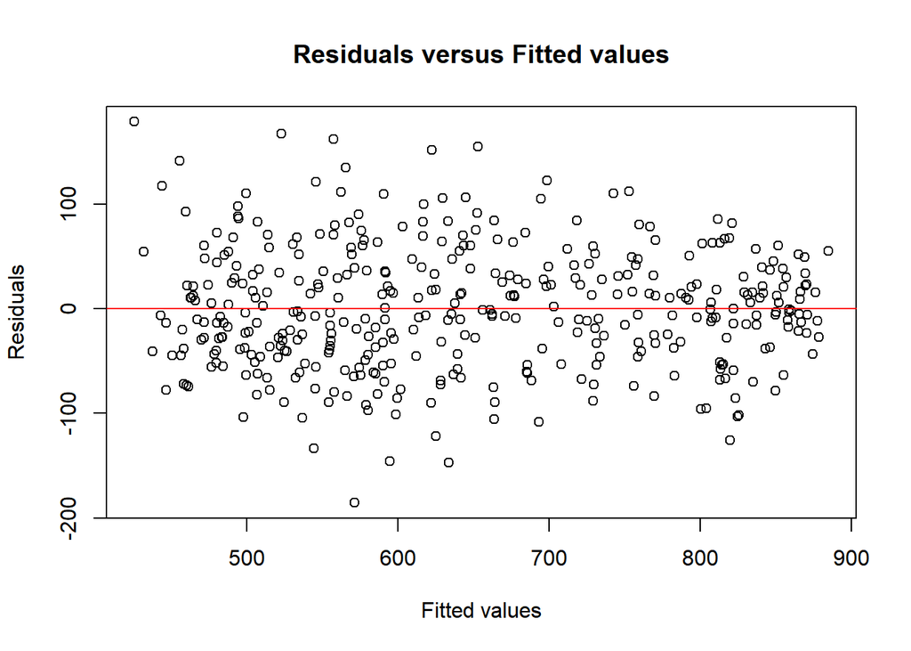

```r
## plot residuals versus fitted values
plot(resid ~ fitted, data = rstd,
     main = "Residuals versus Fitted values",
     xlab = "Fitted values",
     ylab = "Residuals")
## Add a horizontal red line to indicate 0
abline(h = 0, col = "red")
```

We see that the pattern of the data points is getting a little narrower towards the right end, which is an indication of heteroscedasticity.

Now let’s look at the Breusch-Pagan test for heteroskedasticity.

```r
## Perform  the Breusch-Pagan test
hettest(reg)
```

```
#> _______________________________________________________________
#>
#>           Breusch-Pagan test for heteroskedasticity
#> _______________________________________________________________
#>
#>    Null Hypothesis |              Variables Chi2(1) Prob > Chi2
#>  ----------------- + ---------------------- ------- -----------
#>  Constant variance | Fitted values of api00    8.89     0.03080
#>  ----------------- + ---------------------- ------- -----------
#> _______________________________________________________________
```

```r
## Studentized version
hettest(reg, studentize = TRUE)
```

```
#> _______________________________________________________________
#>
#>     Studentized Breusch-Pagan test for heteroskedasticity
#> _______________________________________________________________
#>
#>    Null Hypothesis |              Variables Chi2(1) Prob > Chi2
#>  ----------------- + ---------------------- ------- -----------
#>  Constant variance | Fitted values of api00    8.39     0.03858
#>  ----------------- + ---------------------- ------- -----------
#> _______________________________________________________________
```

if the p-value is very small, we would have to reject the hypothesis and accept the alternative hypothesis that the variance is not homogenous. So in this case, the evidence is against the null hypothesis that the variance is homogeneous. These tests are very sensitive to model assumptions, such as the assumption of normality. Therefore it is a common practice to combine the tests with diagnostic plots to make a judgment on the severity of the heteroscedasticity and to decide if any correction is needed for heteroscedasticity. In our case, the plot above does not show too strong an evidence.

#### 0.0.1.4 Multicollinearity

When there is a perfect linear relationship among the predictors, the estimates for a regression model cannot be uniquely computed. If two variables are near perfect linear combinations of one another and there are more than two variables involved, it is often called `multicollinearity`.

As the degree of multicollinearity increases, the regression model estimates of the coefficients become unstable and the standard errors for the coefficients can get wildly inflated. It means the estimates for the regression coefficients are biased and the conclusion will be incorrect.

Below we use `vif` function from the `car` package by inputting the model fit to predict `api00` from `meals`, `ell` and `emer`.

The `vif` stands for variance inflation factor. As a rule of thumb, a variable whose `VIF` values are greater than 10 may merit further investigation. Tolerance, defined as `1/VIF`, is used by many researchers to check on the degree of collinearity. A tolerance value lower than 0.1 is comparable to a VIF of 10. It means that the variable could be considered as a linear combination of other independent variables.

```r
## vif for the model fit
car::vif(fit)
```

```
#>    meals      ell     emer
#> 2.725056 2.510512 1.414817
```

The `VIF`s look fine here.

Here is an example where the `VIF`s are more worrisome.

```r
## Fit another model
fit <- lm(api00 ~ acs_k3 + avg_ed + grad_sch + col_grad + some_col, data = elemapi2)

## regression report
regress(fit)
```

```
#> _____________________________________________________________________________
#>
#>                 Linear Regression Output
#> _____________________________________________________________________________
#>
#>          Stats |     Value              Source |      DF         SS        MS
#>  ------------- + ---------          ---------- + ------- ---------- ---------
#>  Number of Obs |       379               Model |       5  5056268.5 1011253.7
#>      F(5, 373) |    143.79            Residual |     373  2623191.2    7032.7
#>       Prob > F |   0.00000          ---------- + ------- ---------- ---------
#>      R-Squared |   0.65841               Total |     378  7679459.8   20316.0
#>  Adj R-Squared |   0.65384
#>            AIC |   4440.81                                 Root MSE     83.86
#>  ------------- + --------- -------- ------------ ------- ---------- ---------
#>          api00 |     Coef.  Std.Err            t   P>|t| [95% Conf. Interval]
#>  ------------- + --------- -------- ------------ ------- ---------- ---------
#>         acs_k3 |  11.45725  3.27541         3.50 0.00053    5.03745  17.87706
#>         avg_ed | 227.26382 37.21960         6.11 0.00000  154.31341 300.21423
#>       grad_sch |  -2.09090  1.35229        -1.55 0.12291   -4.74139   0.55959
#>       col_grad |  -2.96783  1.01781        -2.92 0.00376   -4.96274  -0.97292
#>       some_col |  -0.76045  0.81097        -0.94 0.34900   -2.34995   0.82904
#>    (Intercept) | -82.60913 81.84638        -1.01 0.31348 -243.02804  77.80978
#>  ------------- + --------- -------- ------------ ------- ---------- ---------
#> _____________________________________________________________________________
#> (Fit: lm(formula = api00 ~ acs_k3 + avg_ed + grad_sch + col_grad +      some_col
#> , data = elemapi2))
#> (acs_k3: avg class size k-3)
#> (avg_ed: avg parent ed)
#> (grad_sch: parent grad school)
#> (col_grad: parent college grad)
#> (some_col: parent some college)
#> (api00: api 2000)
```

```r
## Check vif
car::vif(fit)
```

```
#>    acs_k3    avg_ed  grad_sch  col_grad  some_col
#>  1.028947 43.570329 14.864590 14.778836  4.065150
```

In this example, the `VIF`values for `avg_ed`, `grad_sch` and `col_grad` are worrisome. All of these variables measure education of the parents and the very high `VIF` values indicate that these variables are possibly redundant. For example, after you know `grad_sch` and `col_grad`, you probably can predict `avg_ed` very well. In this example, multicollinearity arises because we have put in too many variables that measure the same thing, parent education.

Let’s omit one of the parent education variables, `avg_ed`.

```r
## Fit another model: omit avg_ed
fit <- lm(api00 ~ acs_k3 + grad_sch + col_grad + some_col, data = elemapi2)

## regression report
regress(fit)
```

```
#> _____________________________________________________________________________
#>
#>                 Linear Regression Output
#> _____________________________________________________________________________
#>
#>          Stats |     Value              Source |      DF         SS        MS
#>  ------------- + ---------          ---------- + ------- ---------- ---------
#>  Number of Obs |       398               Model |       4  4180144.3 1045036.1
#>      F(4, 393) |    107.12            Residual |     393  3834062.8    9755.9
#>       Prob > F |   0.00000          ---------- + ------- ---------- ---------
#>      R-Squared |   0.52159               Total |     397  8014207.1   20186.9
#>  Adj R-Squared |   0.51672
#>            AIC |   4792.32                                 Root MSE     98.77
#>  ------------- + --------- -------- ------------ ------- ---------- ---------
#>          api00 |     Coef.  Std.Err            t   P>|t| [95% Conf. Interval]
#>  ------------- + --------- -------- ------------ ------- ---------- ---------
#>         acs_k3 |  11.71260  3.66487         3.20 0.00151    4.52945  18.89575
#>       grad_sch |   5.63476  0.45820        12.30 0.00000    4.73669   6.53283
#>       col_grad |   2.47992  0.33955         7.30 0.00000    1.81439   3.14544
#>       some_col |   2.15827  0.44388         4.86 0.00000    1.28826   3.02828
#>    (Intercept) | 283.74462 70.32475         4.03 0.00007  145.90810 421.58113
#>  ------------- + --------- -------- ------------ ------- ---------- ---------
#> _____________________________________________________________________________
#> (Fit: lm(formula = api00 ~ acs_k3 + grad_sch + col_grad + some_col,      data =
#> elemapi2))
#> (acs_k3: avg class size k-3)
#> (grad_sch: parent grad school)
#> (col_grad: parent college grad)
#> (some_col: parent some college)
#> (api00: api 2000)
```

```r
## Check vif
car::vif(fit)
```

```
#>   acs_k3 grad_sch col_grad some_col
#> 1.023891 1.262417 1.277586 1.034451
```

The `VIF` values in the analysis here appear much better. Also, note how the standard errors are reduced for the parent education variables, `grad_sch` and `col_grad`. This is because the high degree of collinearity caused the standard errors to be inflated. With the multicollinearity eliminated, the coefficient for `grad_sch`, which had been non-significant, is now significant.

#### 0.0.1.5 Linearity

When we do linear regression, we assume that the relationship between the response variable and the predictors is linear. This is the assumption of linearity. If this assumption is violated, the linear regression will try to fit a straight line to data that does not follow a straight line. Checking the linear assumption in the case of simple regression is straightforward, since we only have one predictor. All we have to do is a scatter plot between the response variable and the predictor to see if nonlinearity is present, such as a curved band or a big wave-shaped curve.

```r
## Fit the model for api00 and enroll
fit <- lm(api00 ~ enroll, data = elemapi2)

## regression report
reg <- regress(fit)
```

```
#> _____________________________________________________________________________
#>
#>                 Linear Regression Output
#> _____________________________________________________________________________
#>
#>          Stats |     Value              Source |      DF         SS        MS
#>  ------------- + ---------          ---------- + ------- ---------- ---------
#>  Number of Obs |       400               Model |       1   817326.3  817326.3
#>      F(1, 398) |     44.83            Residual |     398  7256345.7   18232.0
#>       Prob > F |   0.00000          ---------- + ------- ---------- ---------
#>      R-Squared |   0.10123               Total |     399  8073672.0   20234.8
#>  Adj R-Squared |   0.09898
#>            AIC |   5063.52                                 Root MSE    135.03
#>  ------------- + --------- -------- ------------ ------- ---------- ---------
#>          api00 |     Coef.  Std.Err            t   P>|t| [95% Conf. Interval]
#>  ------------- + --------- -------- ------------ ------- ---------- ---------
#>         enroll |  -0.19987  0.02985        -6.70 0.00000   -0.25838  -0.14136
#>    (Intercept) | 744.25141 15.93308        46.71 0.00000  713.02258 775.48025
#>  ------------- + --------- -------- ------------ ------- ---------- ---------
#> _____________________________________________________________________________
#> (Fit: lm(formula = api00 ~ enroll, data = elemapi2))
#> (enroll: number of students)
#> (api00: api 2000)
```

Below we create a scatter plot with a regression line and a lowess smoother.

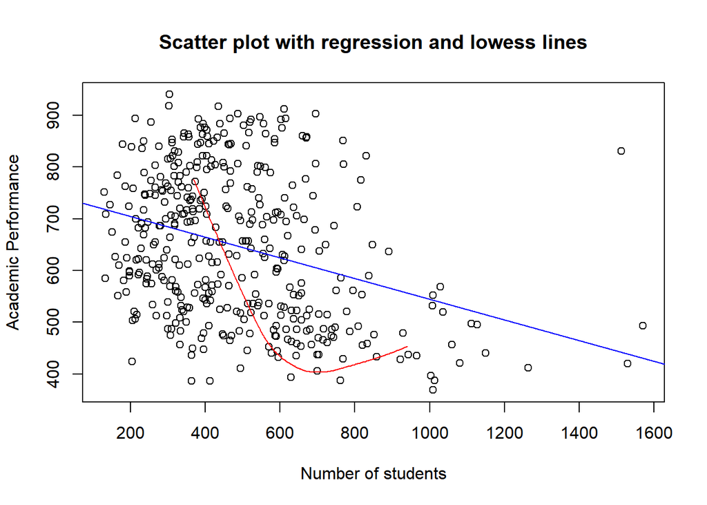

```r
## Create scatter plot api00 ~ enroll
plot(api00 ~ enroll, data = elemapi2,
     main = "Scatter plot with regression and lowess lines",
     xlab = "Number of students",
     ylab = "Academic Performance")

## Add regression line
abline(fit, col = "blue")

## Add lowess smoother
elemapi2 %$% lines(lowess(api00, enroll), col = "red")
```

Checking the linearity assumption is not so straightforward in the case of multiple regression.

The most straightforward thing to do is to plot the standardized residuals against each of the predictor variables in the regression model. If there is a clear nonlinear pattern, there is a problem of nonlinearity. Otherwise, we should see for each of the plots just a random scatter of points.

**Component residual plots**

They are an extension of `partial residual plots` to examine if the predictors have a linear relationship to the dependent variable. A partial residual plot essentially attempts to model the residuals of one predictor against the dependent variable. A component residual plot adds a line indicating where the line of best fit lies. A significant difference between the residual line and the component line indicates that the predictor does not have a linear relationship with the dependent variable.

Below we generate a component residual plota for the model fit by using `crPlots` function from `car` package.

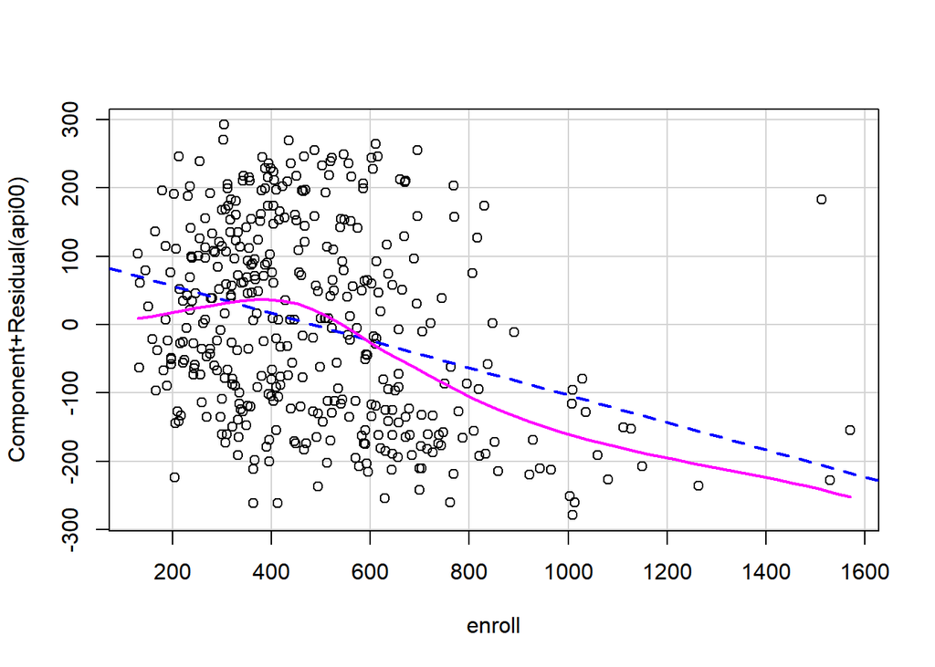

```r
## Component residual plots
car::crPlots(fit)
```

The plot shown above does not strongly indicate a clear departure from linearity.

**nations data**

Let’s look at a more interesting example. This example is taken from “Statistics with Stata 5” by Lawrence C. Hamilton (1997, Duxbery Press). The dataset we will use is called `nations`.

Let’s import the dataset and fit a model that predicts birth rate (`birth`), from per capita gross national product (`gnpcap`), and urban population (`urban`). If this were a complete regression analysis, we would start with examining the variables, but for the purpose of illustrating nonlinearity, we will jump directly to the regression and create component residual plots to identify the non-linearity problem.

```r
## Import nations dataset
nations <- haven::read_dta("https://stats.idre.ucla.edu/stat/stata/examples/sws5/nations.dta")

## Check the dataset
codebook(nations)
```

```
#> _______________________________________________________________________________
#>
#> Codebook: 'nations'
#> _______________________________________________________________________________
#>
#>  No Variable |                             Label      Type Obs_Num <NA> <NA>(%)
#>  -- -------- + --------------------------------- --------- ------- ---- -------
#>   1  country |                           Country character     109    0       0
#>   2      pop |       1985 population in millions   numeric     109    0       0
#>   3    birth |      Crude birth rate/1000 people   numeric     109    0       0
#>   4    death |      Crude death rate/1000 people   numeric     109    0       0
#>   5 chldmort |     Child (1-4 yr) mortality 1985   numeric     109    0       0
#>   6  infmort |     Infant (<1 yr) mortality 1985   numeric     109    0       0
#>   7     life |     Life expectancy at birth 1985   numeric     109    0       0
#>   8     food |    Per capita daily calories 1985   numeric     108    1     0.9
#>   9   energy | Per cap energy consumed, kg oi...   numeric     107    2     1.8
#>  10   gnpcap |               Per capita GNP 1985   numeric     109    0       0
#>  11   gnpgro |         Annual GNP growth % 65-85   numeric     102    7     6.4
#>  12    urban |           % population urban 1985   numeric     108    1     0.9
#>  13  school1 |    Primary enrollment % age-group   numeric     104    5     4.6
#>  14  school2 |      Secondary enroll % age-group   numeric     104    5     4.6
#>  15  school3 |     Higher ed. enroll % age-group   numeric     100    9     8.3
#>  -- -------- + --------------------------------- --------- ------- ---- -------
#> _______________________________________________________________________________
#> (Dataset Label: Data on 109 countries)
```

```r
## Fit a new model
fit <- lm(birth ~ gnpcap + urban, data = nations)

## Regression report
regress(fit)
```

```
#> ___________________________________________________________________________
#>
#>                 Linear Regression Output
#> ___________________________________________________________________________
#>
#>          Stats |    Value             Source |      DF         SS        MS
#>  ------------- + --------         ---------- + ------- ---------- ---------
#>  Number of Obs |      108              Model |       2    10796.5    5398.2
#>      F(2, 105) |    64.22           Residual |     105     8825.6      84.1
#>       Prob > F |  0.00000         ---------- + ------- ---------- ---------
#>      R-Squared |  0.55022              Total |     107    19622.1     183.4
#>  Adj R-Squared |  0.54165
#>            AIC |   790.04                                Root MSE      9.17
#>  ------------- + -------- ------- ------------ ------- ---------- ---------
#>          birth |    Coef. Std.Err            t   P>|t| [95% Conf. Interval]
#>  ------------- + -------- ------- ------------ ------- ---------- ---------
#>         gnpcap | -0.00084 0.00026        -3.19 0.00186   -0.00136  -0.00033
#>          urban | -0.28232 0.04622        -6.11 0.00000   -0.37291  -0.19173
#>    (Intercept) | 48.85603 1.98691        24.59 0.00000   44.96169  52.75037
#>  ------------- + -------- ------- ------------ ------- ---------- ---------
#> ___________________________________________________________________________
#> (Fit: lm(formula = birth ~ gnpcap + urban, data = nations))
#> (gnpcap: Per capita GNP 1985)
#> (urban: % population urban 1985)
#> (birth: Crude birth rate/1000 people)
```

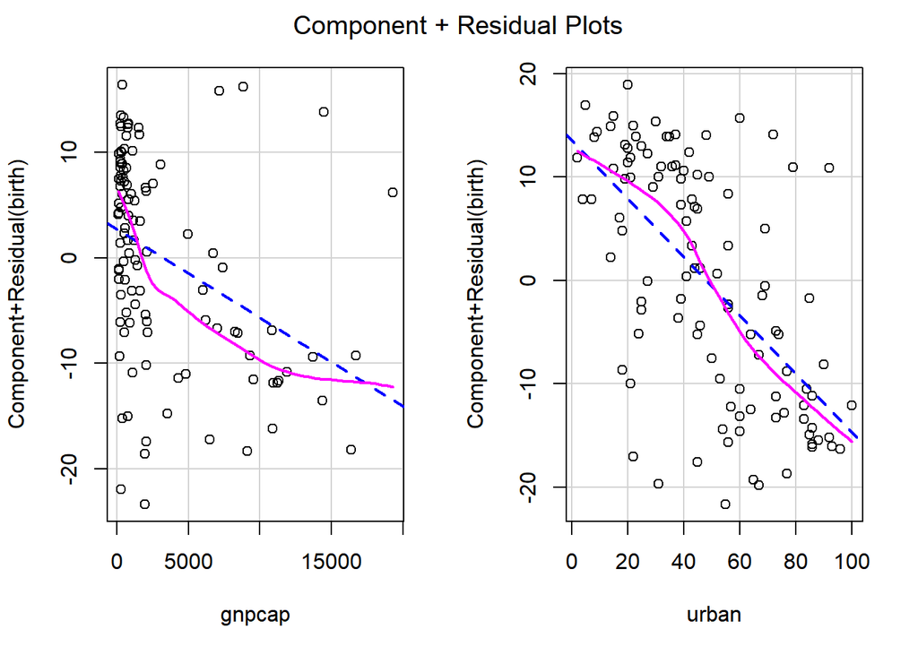

```r
## crPlots from car package
car::crPlots(fit)
```

The acprplot plot for gnpcap shows clear deviation from linearity and the one for urban does not show nearly as much deviation from linearity.

Below we create a scatter plot matrix to look each variable closely.

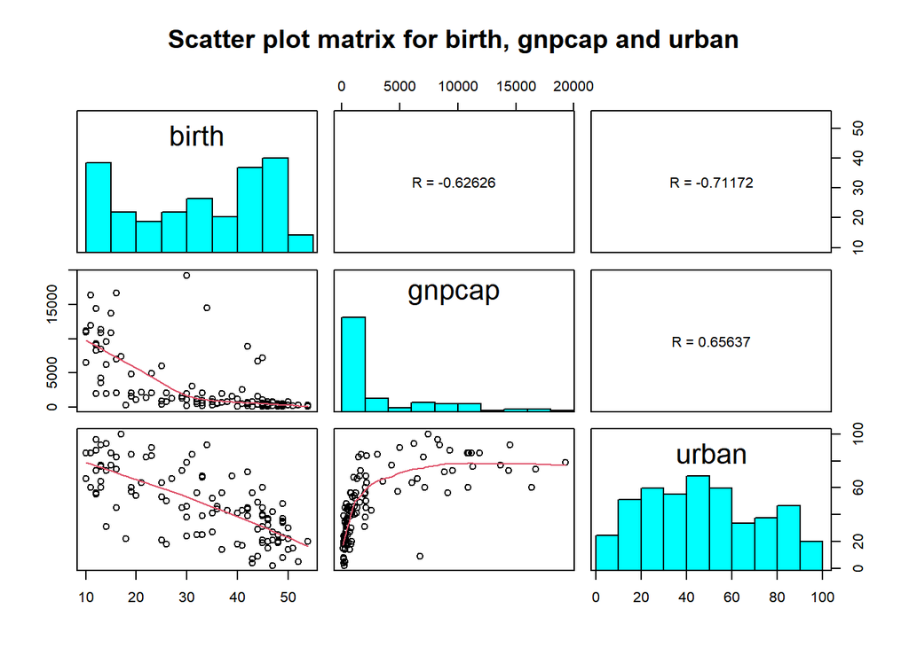

```r
## Scatter Plot Matrix for birth gnpcap urban
nations %>%
  select(birth, gnpcap, urban) %>%
  scatterPlotMatrix(main = "Scatter plot matrix for birth, gnpcap and urban")
```

We see that the relation between birth rate and per capita gross national product is clearly nonlinear and the relation between birth rate and urban population is not too far off from being linear.

Let’s use `ladder` function to generate transformation powers to convert `gnpcap` to normal distribution.

```r
## Ladder transformation
ladder(nations, gnpcap)
```

```
#> _____________________________________________________
#>
#> Ladder of Transformation
#> _____________________________________________________
#>
#>     Transformation |          formula       W P-Value
#>  ----------------- + ---------------- ------- -------
#>               cube |         gnpcap^3 0.40800 0.00000
#>              squre |         gnpcap^2 0.52742 0.00000
#>                raw |           gnpcap 0.70398 0.00000
#>        square-root |     sqrt(gnpcap) 0.83290 0.00000
#>                log |      log(gnpcap) 0.94463 0.00019
#>    reciprocal root | 1 / sqrt(gnpcap) 0.93074 0.00003
#>         reciprocal |       1 / gnpcap 0.81437 0.00000
#>  reciprocal square |   1 / (gnpcap^2) 0.57682 0.00000
#>    reciprocal cube |   1 / (gnpcap^3) 0.41503 0.00000
#>  ----------------- + ---------------- ------- -------
#> _____________________________________________________
```

The `log` transformation shows the largest `W` and p-value.

Let’s transform `gnpcap` to `log` scale.

```r
## Tranform gnpcap to log scale
nations <- generate(nations, lggnp, log(gnpcap))
```

```
#> ('lggnp' generated 109 valid values)
```

```r
## make two histograms of the gnpcap and lggnp
par(mfrow = c(1, 2))
histogram(nations, gnpcap, xlab = "GNP per capita")
```

```
#> (A histogram is drawn for 'gnpcap' with overlay normal curve)
```

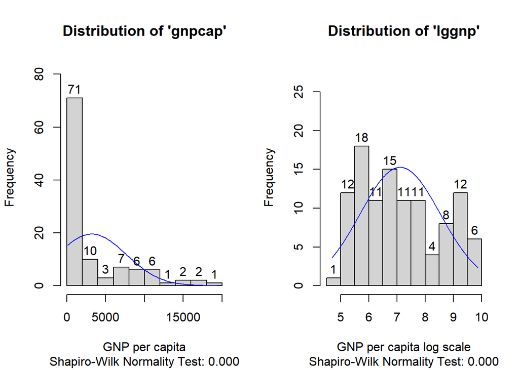

[output not shown]

```r
histogram(nations, lggnp, xlab = "GNP per capita log scale")
```

The transformation does seem to help correct the skewness greatly. Next, let’s do the regression again replacing gnpcap by lggnp.

```r
## Fit the model by replacing gnpcap with lggnp
fit <- lm(birth ~ lggnp + urban, data = nations)

## Regression report
regress(fit)
```

```
#> ___________________________________________________________________________
#>
#>                 Linear Regression Output
#> ___________________________________________________________________________
#>
#>          Stats |    Value             Source |      DF         SS        MS
#>  ------------- + --------         ---------- + ------- ---------- ---------
#>  Number of Obs |      108              Model |       2    11618.0    5809.0
#>      F(2, 105) |    76.20           Residual |     105     8004.0      76.2
#>       Prob > F |  0.00000         ---------- + ------- ---------- ---------
#>      R-Squared |  0.59209              Total |     107    19622.1     183.4
#>  Adj R-Squared |  0.58432
#>            AIC |   779.49                                Root MSE      8.73
#>  ------------- + -------- ------- ------------ ------- ---------- ---------
#>          birth |    Coef. Std.Err            t   P>|t| [95% Conf. Interval]
#>  ------------- + -------- ------- ------------ ------- ---------- ---------
#>          lggnp | -4.87769 1.03948        -4.69 0.00001   -6.91506  -2.84031
#>          urban | -0.15625 0.05796        -2.70 0.00818   -0.26986  -0.04265
#>    (Intercept) | 74.87778 5.43965        13.77 0.00000   64.21606  85.53950
#>  ------------- + -------- ------- ------------ ------- ---------- ---------
#> ___________________________________________________________________________
#> (Fit: lm(formula = birth ~ lggnp + urban, data = nations))
#> (lggnp: log(gnpcap))
#> (urban: % population urban 1985)
#> (birth: Crude birth rate/1000 people)
```

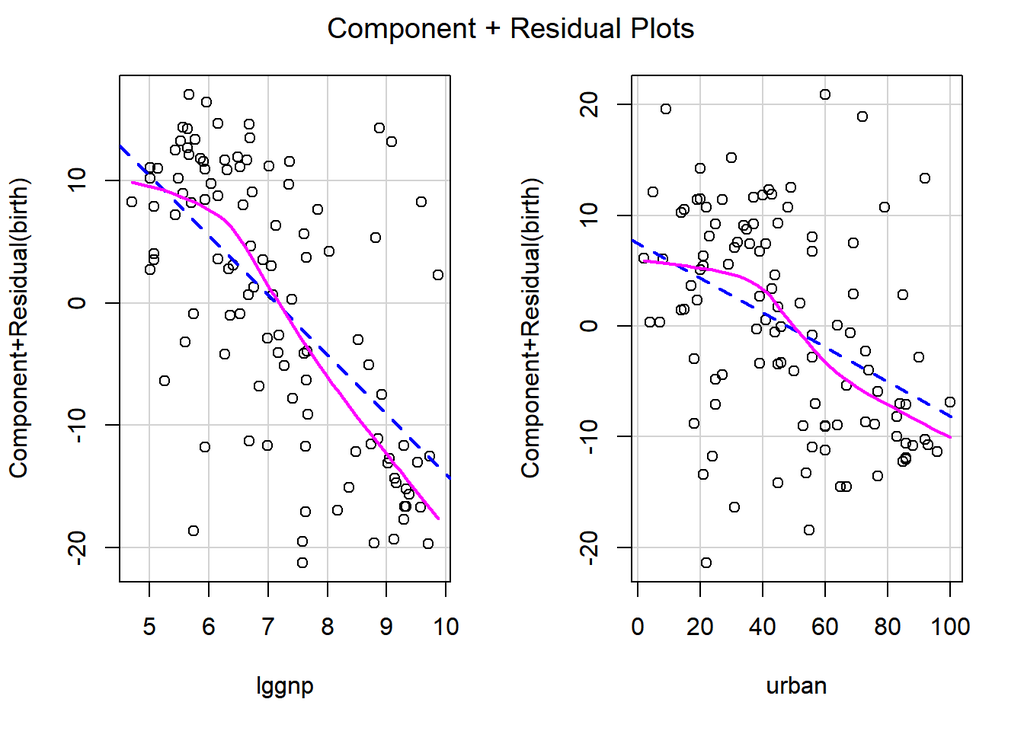

```r
## Component residual plots
car::crPlots(fit)
```

The plot above shows less deviation from nonlinearity than before, though the problem of nonlinearity has not been completely solved yet.

#### 0.0.1.6 Model Specification

A model specification error can occur when one or more relevant variables are omitted from the model or one or more irrelevant variables are included in the model. If relevant variables are omitted from the model, the common variance they share with included variables may be wrongly attributed to those variables, and the error term is inflated. On the other hand, if irrelevant variables are included in the model, the common variance they share with included variables may be wrongly attributed to them. Model specification errors can substantially affect the estimate of regression coefficients.

Consider the model below. This regression suggests that as class size increases the academic performance increases. Before we publish results saying that increased class size is associated with higher academic performance, let’s check the model specification.

```r
## Fit the model api00 acs_k3
fit <- lm(api00 ~ acs_k3, data = elemapi2)

## Regression report
regress(fit)
```

```
#> _____________________________________________________________________________
#>
#>                 Linear Regression Output
#> _____________________________________________________________________________
#>
#>          Stats |     Value              Source |      DF         SS        MS
#>  ------------- + ---------          ---------- + ------- ---------- ---------
#>  Number of Obs |       398               Model |       1   234353.8  234353.8
#>      F(1, 396) |     11.93            Residual |     396  7779853.3   19646.1
#>       Prob > F |   0.00061          ---------- + ------- ---------- ---------
#>      R-Squared |   0.02924               Total |     397  8014207.1   20186.9
#>  Adj R-Squared |   0.02679
#>            AIC |   5067.95                                 Root MSE    140.16
#>  ------------- + --------- -------- ------------ ------- ---------- ---------
#>          api00 |     Coef.  Std.Err            t   P>|t| [95% Conf. Interval]
#>  ------------- + --------- -------- ------------ ------- ---------- ---------
#>         acs_k3 |  17.75148  5.13969         3.45 0.00061    7.67770  27.82527
#>    (Intercept) | 308.33716 98.73085         3.12 0.00192  114.82470 501.84962
#>  ------------- + --------- -------- ------------ ------- ---------- ---------
#> _____________________________________________________________________________
#> (Fit: lm(formula = api00 ~ acs_k3, data = elemapi2))
#> (acs_k3: avg class size k-3)
#> (api00: api 2000)
```

There are a couple of methods to detect specification errors.

Below, we performs `linkTest` which is a model specification link test for single-equation models. The `linkTest` is based on the idea that if a regression is properly specified, one should not be able to find any additional independent variables that are significant except by chance. `linkTest` creates two new variables, the variable of prediction, hat_, and the variable of squared prediction, `hatsq_`. The model is then refit using these two variables as predictors. hat_ should be significant since it is the predicted value. On the other hand, `hatsq_` shouldn’t, because if our model is specified correctly, the squared predictions should not have much explanatory power. That is we would not expect `hatsq_` to be a significant predictor if our model is specified correctly. So we will be looking at the p-value for `hatsq_`.

```r
## Perform linkTest
linkTest(fit, rnd = 2)
```

```
#> ________________________________________________________________________
#>
#>                 Linear Regression Output
#> ________________________________________________________________________
#>
#>          Stats |   Value             Source |    DF         SS        MS
#>  ------------- + -------         ---------- + ----- ---------- ---------
#>  Number of Obs |     398              Model |     2   277706.6  138853.3
#>      F(2, 395) |    7.09           Residual |   395  7736500.5   19586.1
#>       Prob > F |    0.00         ---------- + ----- ---------- ---------
#>      R-Squared |    0.03              Total |   397  8014207.1   20186.9
#>  Adj R-Squared |    0.03
#>            AIC | 5067.73                              Root MSE    139.95
#>  ------------- + ------- ------- ------------ ----- ---------- ---------
#>          api00 |   Coef. Std.Err            t P>|t| [95% Conf. Interval]
#>  ------------- + ------- ------- ------------ ----- ---------- ---------
#>           hat_ |  -11.05    8.10        -1.36  0.17     -26.94      4.83
#>         hatsq_ |    0.01    0.01         1.49  0.14      -0.00      0.02
#>    (Intercept) | 3884.51 2617.70         1.48  0.14   -1246.18   9015.19
#>  ------------- + ------- ------- ------------ ----- ---------- ---------
#> ________________________________________________________________________
#> (Fit: lm(formula = api00 ~ hat_ + hatsq_, data = elemapi2_linkTest))
#> (api00: api 2000)
```

From the above `linkTest`, the test of `hatsq_` is not significant. This is to say that `linkTest` has failed to reject the assumption that the model is specified correctly. Therefore, it seems to us that we don’t have a specification error.

Let’s try adding the variable `full` to the model.

```r
## Fit the model api00 acs_k3 full
fit <- lm(api00 ~ acs_k3 + full, data = elemapi2)

## Regression report
regress(fit)
```

```
#> ____________________________________________________________________________
#>
#>                 Linear Regression Output
#> ____________________________________________________________________________
#>
#>          Stats |    Value              Source |      DF         SS        MS
#>  ------------- + --------          ---------- + ------- ---------- ---------
#>  Number of Obs |      398               Model |       2  2715101.9 1357550.9
#>      F(2, 395) |   101.19            Residual |     395  5299105.2   13415.5
#>       Prob > F |  0.00000          ---------- + ------- ---------- ---------
#>      R-Squared |  0.33879               Total |     397  8014207.1   20186.9
#>  Adj R-Squared |  0.33544
#>            AIC |  4917.12                                 Root MSE    115.83
#>  ------------- + -------- -------- ------------ ------- ---------- ---------
#>          api00 |    Coef.  Std.Err            t   P>|t| [95% Conf. Interval]
#>  ------------- + -------- -------- ------------ ------- ---------- ---------
#>         acs_k3 |  8.35568  4.30302         1.94 0.05287   -0.07824  16.78961
#>           full |  5.38979  0.39635        13.60 0.00000    4.61293   6.16664
#>    (Intercept) | 32.21346 84.07525         0.38 0.70181 -132.57403 197.00095
#>  ------------- + -------- -------- ------------ ------- ---------- ---------
#> ____________________________________________________________________________
#> (Fit: lm(formula = api00 ~ acs_k3 + full, data = elemapi2))
#> (acs_k3: avg class size k-3)
#> (full: pct full credential)
#> (api00: api 2000)
```

```r
## Perform linkTest
linkTest(fit)
```

```
#> _______________________________________________________________________________
#>
#>                 Linear Regression Output
#> _______________________________________________________________________________
#>
#>          Stats |     Value               Source |      DF         SS         MS
#>  ------------- + ---------           ---------- + ------- ---------- ----------
#>  Number of Obs |       398                Model |       2  2838564.4  1419282.2
#>      F(2, 395) |    108.32             Residual |     395  5175642.7    13102.9
#>       Prob > F |   0.00000           ---------- + ------- ---------- ----------
#>      R-Squared |   0.35419                Total |     397  8014207.1    20186.9
#>  Adj R-Squared |   0.35092
#>            AIC |   4907.74                                  Root MSE     114.47
#>  ------------- + --------- --------- ------------ ------- ---------- ----------
#>          api00 |     Coef.   Std.Err            t   P>|t| [95% Conf.  Interval]
#>  ------------- + --------- --------- ------------ ------- ---------- ----------
#>           hat_ |  -1.86890   0.93719        -1.99 0.04682   -3.70579   -0.03201
#>         hatsq_ |   0.00234   0.00076         3.07 0.00229    0.00085    0.00384
#>    (Intercept) | 858.87275 283.45952         3.03 0.00261  303.29209 1414.45341
#>  ------------- + --------- --------- ------------ ------- ---------- ----------
#> _______________________________________________________________________________
#> (Fit: lm(formula = api00 ~ hat_ + hatsq_, data = elemapi2_linkTest))
#> (api00: api 2000)
```

The p-value indicates that we have a specification problems.

Next we add `meals` to the model.

```r
## Fit the model api00 acs_k3 full meals
fit <- lm(api00 ~ acs_k3 + full + meals, data = elemapi2)

## Regression report
regress(fit)
```

```
#> _____________________________________________________________________________
#>
#>                 Linear Regression Output
#> _____________________________________________________________________________
#>
#>          Stats |     Value              Source |      DF         SS        MS
#>  ------------- + ---------          ---------- + ------- ---------- ---------
#>  Number of Obs |       398               Model |       3  6604966.2 2201655.4
#>      F(3, 394) |    615.55            Residual |     394  1409241.0    3576.8
#>       Prob > F |   0.00000          ---------- + ------- ---------- ---------
#>      R-Squared |   0.82416               Total |     397  8014207.1   20186.9
#>  Adj R-Squared |   0.82282
#>            AIC |   4391.97                                 Root MSE     59.81
#>  ------------- + --------- -------- ------------ ------- ---------- ---------
#>          api00 |     Coef.  Std.Err            t   P>|t| [95% Conf. Interval]
#>  ------------- + --------- -------- ------------ ------- ---------- ---------
#>         acs_k3 |  -0.71706  2.23882        -0.32 0.74892   -5.10515   3.67103
#>           full |   1.32714  0.23887         5.56 0.00000    0.85895   1.79533
#>          meals |  -3.68626  0.11178       -32.98 0.00000   -3.90535  -3.46718
#>    (Intercept) | 771.65811 48.86071        15.79 0.00000  675.89111 867.42510
#>  ------------- + --------- -------- ------------ ------- ---------- ---------
#> _____________________________________________________________________________
#> (Fit: lm(formula = api00 ~ acs_k3 + full + meals, data = elemapi2))
#> (acs_k3: avg class size k-3)
#> (full: pct full credential)
#> (meals: pct free meals)
#> (api00: api 2000)
```

```r
## Perform linkTest
linkTest(fit)
```

```
#> ______________________________________________________________________________
#>
#>                 Linear Regression Output
#> ______________________________________________________________________________
#>
#>          Stats |      Value              Source |      DF         SS        MS
#>  ------------- + ----------          ---------- + ------- ---------- ---------
#>  Number of Obs |        398               Model |       2  6612479.8 3306239.9
#>      F(2, 395) |     931.68            Residual |     395  1401727.4    3548.7
#>       Prob > F |    0.00000          ---------- + ------- ---------- ---------
#>      R-Squared |    0.82509               Total |     397  8014207.1   20186.9
#>  Adj R-Squared |    0.82421
#>            AIC |    4387.85                                 Root MSE     59.57
#>  ------------- + ---------- -------- ------------ ------- ---------- ---------
#>          api00 |      Coef.  Std.Err            t   P>|t| [95% Conf. Interval]
#>  ------------- + ---------- -------- ------------ ------- ---------- ---------
#>           hat_ |    1.42433  0.29254         4.87 0.00000    0.85096   1.99770
#>         hatsq_ |   -0.00032  0.00022        -1.46 0.14644   -0.00074   0.00011
#>    (Intercept) | -136.51045 95.05904        -1.44 0.15178 -322.82617  49.80528
#>  ------------- + ---------- -------- ------------ ------- ---------- ---------
#> ______________________________________________________________________________
#> (Fit: lm(formula = api00 ~ hat_ + hatsq_, data = elemapi2_linkTest))
#> (api00: api 2000)
```

Note that after including meals and `full`, the coefficient for class size is no longer significant. While `acs_k3` does have a positive relationship with `api00` when no other variables are in the model, when we include, and hence control for, other important variables, `acs_k3` is no longer significantly related to `api00` and its relationship to `api00` is no longer positive.

#### 0.0.1.7 Independence

The statement of this assumption that the errors associated with one observation are not correlated with the errors of any other observation cover several different situations. Consider the case of collecting data from students in eight different elementary schools. It is likely that the students within each school will tend to be more like one another than students from different schools, that is, their errors are not independent.

Another way in which the assumption of independence can be broken is when data are collected on the same variables over time. Let’s say that we collect truancy data every semester for 12 years. In this situation it is likely that the errors for observation between adjacent semesters will be more highly correlated than for observations more separated in time. This is known as autocorrelation.

We don’t have any time-series data, so we will use the elemapi2 dataset and pretend that snum indicates the time at which the data were collected.

A simple visual check would be to plot the residuals versus the time variable.

Below we fit the model for `api00` with `enroll`.

```r
## Fit the model api00 enroll
fit <- lm(api00 ~ enroll, data = elemapi2)

## Regression report
reg <- regress(fit)
```

```
#> _____________________________________________________________________________
#>
#>                 Linear Regression Output
#> _____________________________________________________________________________
#>
#>          Stats |     Value              Source |      DF         SS        MS
#>  ------------- + ---------          ---------- + ------- ---------- ---------
#>  Number of Obs |       400               Model |       1   817326.3  817326.3
#>      F(1, 398) |     44.83            Residual |     398  7256345.7   18232.0
#>       Prob > F |   0.00000          ---------- + ------- ---------- ---------
#>      R-Squared |   0.10123               Total |     399  8073672.0   20234.8
#>  Adj R-Squared |   0.09898
#>            AIC |   5063.52                                 Root MSE    135.03
#>  ------------- + --------- -------- ------------ ------- ---------- ---------
#>          api00 |     Coef.  Std.Err            t   P>|t| [95% Conf. Interval]
#>  ------------- + --------- -------- ------------ ------- ---------- ---------
#>         enroll |  -0.19987  0.02985        -6.70 0.00000   -0.25838  -0.14136
#>    (Intercept) | 744.25141 15.93308        46.71 0.00000  713.02258 775.48025
#>  ------------- + --------- -------- ------------ ------- ---------- ---------
#> _____________________________________________________________________________
#> (Fit: lm(formula = api00 ~ enroll, data = elemapi2))
#> (enroll: number of students)
#> (api00: api 2000)
```

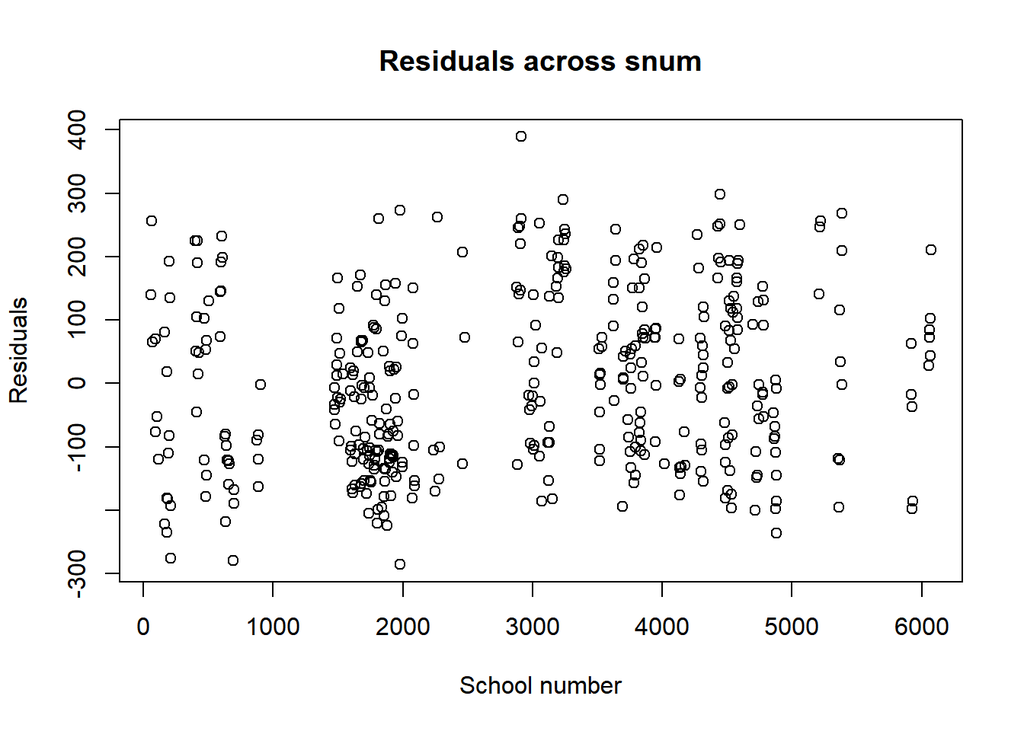

```r
## Predict model diagnostic statistics
rstd <- predict(reg)

## Plots residuals versus time variable 'snum'
plot(resid ~ snum, data = rstd,
     main = "Residuals across snum",
     xlab = "School number",
     ylab = "Residuals")
```

#### 0.0.1.8 Summary

We have used a number of tools in R for determining whether our data meets the regression assumptions. Below, we list the functions we demonstrated according to the assumptions.

**Detecting Influential Data**

- `scatterPlotMatrix` from `mStats` graphs scatter plot matrices. Input is dataset with desired variables.
- `predict` from `mStats` is used to create predicted or fitted values, residuals, and measures of influence. Input is the output `reg` from `regress` function, although `reg` can be any name you set for the output.
- `plot` from `mStats` graphs four plots for linear model diagnostics. We check residual-versus-fitted plot (the first plot) and residual-versus-leverage plot (the fourth plot).
- ``avPlots` from `car` graphs an added-variable plot, a.k.a. partial regression plot.

**Tests for Normality of Residuals**

- `plot` from `mStats` graphs four plots for linear model diagnostics. We check the normal quantile plot (the second plot)
- `summ` from `mStats` to summarize residuals, `resid` from `rstd` which is obtained from `predict` function. We check the p-value from Shapiro-Wilk test of noramlity shown as `Normality` in the output.

**Tests for Heteroscedasticity**

- `plot` from `mStats` graphs four plots for linear model diagnostics. We check residual-versus-fitted plot (the first plot).
- `hettest` from `mStats` performs the Breusch-Pagan test for heteroscedasticity.

**Test for Multicollinearity**

- `vif` from `car` calculates the variance inflation factor for the independent variables in the linear model.

**Tests for Non-Linearity**

- `plot` from base R graphs a scatter plot with linear regression and lowess smoother lines. It requires additional functions, `abline` and `Lines`.
- `crPlots` from `car` graphs a component residual plot.

**Tests for Model Specification**

- `linkTest` from `mStats` performs a link test for model specification.

#### 0.0.1.9 Exercise

[^1]: REGRESSION WITH STATA CHAPTER 2 – REGRESSION DIAGNOSTICS. UCLA: Statistical Consulting Group. from https://stats.idre.ucla.edu/stata/webbooks/reg/chapter2/stata-webbooksregressionwith-statachapter-2-regression-diagnostics/ (accessed August 22, 2016)
[^2]: REGRESSION WITH STATA CHAPTER 2 – REGRESSION DIAGNOSTICS. UCLA: Statistical Consulting Group. from https://stats.idre.ucla.edu/stata/webbooks/reg/chapter2/stata-webbooksregressionwith-statachapter-2-regression-diagnostics/ (accessed August 22, 2016)